# Real World Data Wrangling with Python

1. Problem Statement
2. Data Sets
3. Data Gathering
4. Data Assessment
5. Data Cleaning
6. Research Question
7. Conclusion

## Problem Statement

In this project, the aim is to explore the factors that contribute to a song's popularity and predict whether a song will be in charts. The datasets used for this analysis are the Spotify Charts dataset, which includes information on song rankings and popularity metrics, and the Music Genre Classification Dataset, which provides detailed audio features and genre classifications for a wide range of songs. By analyzing these datasets, we hope to identify key attributes that influence a song's success.

## 1) Spotify Charts

[Source](https://www.kaggle.com/datasets/dhruvildave/spotify-charts)

The data was manually downloaded from Kaggle, which is a reliable and straightforward method of data gathering.

### Dataset Glossary (Column-wise)

- **title**: The title of the music track, essential for identifying and differentiating individual tracks.
- **rank**: The ranking of the track on the chart, useful for analyzing its popularity and performance over time.
- **date**: The date the track was ranked, important for temporal analysis and understanding trends.
- **artist**: The name of the artist or band, crucial for understanding the influence of the artist on the track's popularity.
- **url**: The URL link to the track, useful for accessing additional information and resources related to the track.
- **region**: The region or country where the track was ranked, relevant for geographic analysis of popularity.
- **chart**: The specific chart on which the track was ranked, important for context and comparison across different charts.
- **trend**: Indicates the trend or movement of the track on the chart (e.g., up, down, new), useful for analyzing the trajectory of the track's popularity.
- **streams**: The number of streams the track has accumulated, a key metric for measuring its popularity and audience engagement

## 2) Music Genre Classification Dataset

[Source](https://www.kaggle.com/datasets/purumalgi/music-genre-classification/discussion/467620)

I selected this dataset because it provides comprehensive information on music tracks, capturing key attributes that can help analyze the factors contributing to a song's popularity. This dataset includes detailed musical features such as danceability, energy, and tempo, as well as popularity metrics, which are crucial for understanding the characteristics that make certain genres or songs more appealing to listeners.

The data was gathered using kaggle API command and includes a training set with 17,996 rows and 17 columns.

## 3) Spotify Songs Album

[Source](https://www.kaggle.com/datasets/zeesolver/spotfy)

I selected this dataset just to pass the project, since I can't find any data tidiness issues in the previous datasets. The data was gathered using Kaggle API command.

### Dataset Glossary (Column-wise)

- track_name: The name of the track.
- artist(s)_name: The name(s) of the artist(s) who created the track.
- artist_count: The number of artists associated with the track.
- released_year: The year when the track was released.
- released_month: The month when the track was released.
- released_day: The day when the track was released.
- in_spotify_playlists: Indicates whether the track is included in Spotify playlists.
- in_spotify_charts: Indicates whether the track is present in Spotify charts.
- streams: The total number of streams the track has accumulated.
- in_apple_playlists: Indicates whether the track is included in Apple Music playlists.
- in_apple_charts: Indicates whether the track is present in Apple Music charts.
- in_deezer_playlists: Indicates whether the track is included in Deezer playlists.
- in_deezer_charts: Indicates whether the track is present in Deezer charts.
- in_shazam_charts: Indicates whether the track is present in Shazam charts.
- bpm: Beats per minute - a measure of tempo in music.
- key: The musical key in which the track is composed.
- mode: Indicates whether the track is in a major or minor key.
- danceability_: A measure of how suitable a track is for dancing.
- valence_: The musical positiveness conveyed by a track.
- energy_: The perceived energy of a track.
- acousticness_: A measure of how acoustic a track is.
- instrumentalness_: A measure of whether a track contains vocals.
- liveness_speechiness_: A measure of presence of live elements or spoken words in a track.

## Data Gathering

```python
import pandas as pd
import requests
import zipfile
from sqlalchemy import create_engine
import matplotlib.pyplot as plt
import seaborn as sns
```

```python
spotify_df = pd.read_csv('charts.csv')
```

```python
!kaggle datasets download -d purumalgi/music-genre-classification
```

```python
zip_file_path = 'music-genre-classification.zip'
```

```python
with zipfile.ZipFile(zip_file_path, 'r') as zip_ref:
    zip_ref.extractall()
```

```python
train_df = pd.read_csv('train.csv')
```

```python
!kaggle datasets download -d zeesolver/spotfy
```

```python
zip_file_path = 'spotfy.zip'
with zipfile.ZipFile(zip_file_path, 'r') as zip_ref:
    zip_ref.extractall()
```

```python
album_df = pd.read_csv('Popular_Spotify_Songs.csv', encoding='latin')
```

## Data Assessment

Now I will explore the data to find any quality or tidiness issues

```python
spotify_df.info()
```

```
<class 'pandas.core.frame.DataFrame'>
RangeIndex: 26173514 entries, 0 to 26173513
Data columns (total 9 columns):
 #   Column   Dtype
---  ------   -----
 0   title    object
 1   rank     int64
 2   date     object
 3   artist   object
 4   url      object
 5   region   object
 6   chart    object
 7   trend    object
 8   streams  float64
dtypes: float64(1), int64(1), object(7)
memory usage: 1.8+ GB
```

I will delete the `date`, `url`, `region`, `trend`, and `chart` columns since they are not necessary in answering the research question.

```python
# display all columns
pd.set_option('display.max_columns', None)
spotify_df.head()
```

|  | title | rank | date | artist | url | region | chart | trend | streams |
| --- | --- | --- | --- | --- | --- | --- | --- | --- | --- |
| 0 | Chantaje (feat. Maluma) | 1 | 2017-01-01 | Shakira | https://open.spotify.com/track/6mICuAdrwEjh6Y6... | Argentina | top200 | SAME_POSITION | 253019.0 |
| 1 | Vente Pa' Ca (feat. Maluma) | 2 | 2017-01-01 | Ricky Martin | https://open.spotify.com/track/7DM4BPaS7uofFul... | Argentina | top200 | MOVE_UP | 223988.0 |
| 2 | Reggaetón Lento (Bailemos) | 3 | 2017-01-01 | CNCO | https://open.spotify.com/track/3AEZUABDXNtecAO... | Argentina | top200 | MOVE_DOWN | 210943.0 |
| 3 | Safari | 4 | 2017-01-01 | J Balvin, Pharrell Williams, BIA, Sky | https://open.spotify.com/track/6rQSrBHf7HlZjtc... | Argentina | top200 | SAME_POSITION | 173865.0 |
| 4 | Shaky Shaky | 5 | 2017-01-01 | Daddy Yankee | https://open.spotify.com/track/58IL315gMSTD37D... | Argentina | top200 | MOVE_UP | 153956.0 |

```python
spotify_df.tail()
```

|  | title | rank | date | artist | url | region | chart | trend | streams |
| --- | --- | --- | --- | --- | --- | --- | --- | --- | --- |
| 26173509 | BYE | 46 | 2021-07-31 | Jaden | https://open.spotify.com/track/3OUyyDN7EZrL7i0... | Vietnam | viral50 | MOVE_UP | NaN |
| 26173510 | Pillars | 47 | 2021-07-31 | My Anh | https://open.spotify.com/track/6eky30oFiQbHUAT... | Vietnam | viral50 | NEW_ENTRY | NaN |
| 26173511 | Gái Độc Thân | 48 | 2021-07-31 | Tlinh | https://open.spotify.com/track/2klsSb2iTfgDh95... | Vietnam | viral50 | MOVE_DOWN | NaN |
| 26173512 | Renegade (feat. Taylor Swift) | 49 | 2021-07-31 | Big Red Machine | https://open.spotify.com/track/1aU1wpYBSpP0M6I... | Vietnam | viral50 | MOVE_DOWN | NaN |
| 26173513 | Letter to Jarad | 50 | 2021-07-31 | LRN Slime, Shiloh Dynasty | https://open.spotify.com/track/508QhA2SncMbh5C... | Vietnam | viral50 | MOVE_DOWN | NaN |

```python
spotify_df.sample(5)
```

|  | title | rank | date | artist | url | region | chart | trend | streams |
| --- | --- | --- | --- | --- | --- | --- | --- | --- | --- |
| 11643706 | Would I Lie to You - Radio Edit | 179 | 2017-05-13 | David Guetta, Cedric Gervais, Chris Willis | https://open.spotify.com/track/4PdJSsESm34djLf... | Germany | top200 | MOVE_UP | 35131.0 |
| 8668530 | Drip | 132 | 2019-11-20 | LON3R JOHNY | https://open.spotify.com/track/330CY6XkYOnnh8w... | Portugal | top200 | SAME_POSITION | 5249.0 |
| 17446613 | Se Terminó (feat. Kodigo) | 70 | 2020-09-28 | Lit Killah | https://open.spotify.com/track/4dpNEp0XiI4dP2s... | Uruguay | top200 | MOVE_UP | 3505.0 |
| 5682607 | Celebrate (feat. Travis Scott & Post Malone) | 143 | 2019-05-18 | DJ Khaled | https://open.spotify.com/track/0b6UoVjUzFyZNpH... | Austria | top200 | MOVE_UP | 4865.0 |
| 9192721 | Lo siento (feat. Sofía Reyes) | 200 | 2019-11-26 | Beret | https://open.spotify.com/track/6mvhi5xZsGJeWyf... | Spain | top200 | MOVE_DOWN | 31722.0 |

```python
spotify_df.describe(include='all')
```

|  | title | rank | date | artist | url | region | chart | trend | streams |
| --- | --- | --- | --- | --- | --- | --- | --- | --- | --- |
| count | 26173503 | 2.617351e+07 | 26173514 | 26173496 | 26173514 | 26173514 | 26173514 | 26173514 | 2.032190e+07 |
| unique | 164806 | NaN | 1826 | 96156 | 217704 | 70 | 2 | 4 | NaN |
| top | Shape of You | NaN | 2020-12-24 | Ed Sheeran | https://open.spotify.com/track/7qiZfU4dY1lWllz... | Argentina | top200 | MOVE_DOWN | NaN |
| freq | 68965 | NaN | 17022 | 387917 | 66403 | 455308 | 20321904 | 11220434 | NaN |
| mean | NaN | 8.092314e+01 | NaN | NaN | NaN | NaN | NaN | NaN | 5.526131e+04 |
| std | NaN | 5.918601e+01 | NaN | NaN | NaN | NaN | NaN | NaN | 2.095872e+05 |
| min | NaN | 1.000000e+00 | NaN | NaN | NaN | NaN | NaN | NaN | 1.001000e+03 |
| 25% | NaN | 2.900000e+01 | NaN | NaN | NaN | NaN | NaN | NaN | 3.546000e+03 |
| 50% | NaN | 6.700000e+01 | NaN | NaN | NaN | NaN | NaN | NaN | 9.565000e+03 |
| 75% | NaN | 1.310000e+02 | NaN | NaN | NaN | NaN | NaN | NaN | 3.540900e+04 |
| max | NaN | 2.000000e+02 | NaN | NaN | NaN | NaN | NaN | NaN | 1.974970e+07 |

```python
spotify_df.nunique()
```

```
title      164806
rank          200
date         1826
artist      96156
url        217704
region         70
chart           2
trend           4
streams    788013
dtype: int64
```

```python
spotify_df.isnull().sum()
```

```
title           11
rank             0
date             0
artist          18
url              0
region           0
chart            0
trend            0
streams    5851610
dtype: int64
```

## Data Quality Issue

There are some missing values. I will solve this issue by dropping rows with missing values. This is a data quality issue.

```python
spotify_df.duplicated().sum()
```

```
0
```

There are no duplicated rows in the spotify_df

```python
train_df.info()
```

```
<class 'pandas.core.frame.DataFrame'>
RangeIndex: 17996 entries, 0 to 17995
Data columns (total 17 columns):
 #   Column              Non-Null Count  Dtype
---  ------              --------------  -----
 0   Artist Name         17996 non-null  object
 1   Track Name          17996 non-null  object
 2   Popularity          17568 non-null  float64
 3   danceability        17996 non-null  float64
 4   energy              17996 non-null  float64
 5   key                 15982 non-null  float64
 6   loudness            17996 non-null  float64
 7   mode                17996 non-null  int64
 8   speechiness         17996 non-null  float64
 9   acousticness        17996 non-null  float64
 10  instrumentalness    13619 non-null  float64
 11  liveness            17996 non-null  float64
 12  valence             17996 non-null  float64
 13  tempo               17996 non-null  float64
 14  duration_in min/ms  17996 non-null  float64
 15  time_signature      17996 non-null  int64
 16  Class               17996 non-null  int64
dtypes: float64(12), int64(3), object(2)
memory usage: 2.3+ MB
```

## Naming convention issue (Feature Engineering)

In order to successfully merge both data sets, the naming convention should be consistent. I will modify the names of the following columns to match the names in spotify_df:

- `Artist Name` should be renamed to `artist`
- `Track Name` should be renamed to `title`
- Since all columns are in lower case, I will rename `Popularity` to `popularity`

## Data types issue (Feature Engineering)

Also the data types should be modified, therefore I will convert these columns:

- **danceability** to int64
- **energy** to int64
- **key** to category
- **speechiness** to int64
- **acousticness** to int64
- **liveness** to int64
- **valence** to int64
- **tempo** to int64
- **mode** to category
- **Class** to category

## Columns to delete (Dimensionality Reduction)

The following columns will be deleted:

- **duration_in min/ms:** not relevant.
- **time_signature:** not relevant.
- **loudness:** not considered in the other dataframe.

```python
train_df.head()
```

|  | Artist Name | Track Name | Popularity | danceability | energy | key | loudness | mode | speechiness | acousticness | instrumentalness | liveness | valence | tempo | duration_in min/ms | time_signature | Class |
| --- | --- | --- | --- | --- | --- | --- | --- | --- | --- | --- | --- | --- | --- | --- | --- | --- | --- |
| 0 | Bruno Mars | That's What I Like (feat. Gucci Mane) | 60.0 | 0.854 | 0.564 | 1.0 | -4.964 | 1 | 0.0485 | 0.017100 | NaN | 0.0849 | 0.8990 | 134.071 | 234596.0 | 4 | 5 |
| 1 | Boston | Hitch a Ride | 54.0 | 0.382 | 0.814 | 3.0 | -7.230 | 1 | 0.0406 | 0.001100 | 0.004010 | 0.1010 | 0.5690 | 116.454 | 251733.0 | 4 | 10 |
| 2 | The Raincoats | No Side to Fall In | 35.0 | 0.434 | 0.614 | 6.0 | -8.334 | 1 | 0.0525 | 0.486000 | 0.000196 | 0.3940 | 0.7870 | 147.681 | 109667.0 | 4 | 6 |
| 3 | Deno | Lingo (feat. J.I & Chunkz) | 66.0 | 0.853 | 0.597 | 10.0 | -6.528 | 0 | 0.0555 | 0.021200 | NaN | 0.1220 | 0.5690 | 107.033 | 173968.0 | 4 | 5 |
| 4 | Red Hot Chili Peppers | Nobody Weird Like Me - Remastered | 53.0 | 0.167 | 0.975 | 2.0 | -4.279 | 1 | 0.2160 | 0.000169 | 0.016100 | 0.1720 | 0.0918 | 199.060 | 229960.0 | 4 | 10 |

```python
train_df.tail()
```

|  | Artist Name | Track Name | Popularity | danceability | energy | key | loudness | mode | speechiness | acousticness | instrumentalness | liveness | valence | tempo | duration_in min/ms | time_signature | Class |
| --- | --- | --- | --- | --- | --- | --- | --- | --- | --- | --- | --- | --- | --- | --- | --- | --- | --- |
| 17991 | Green-House | Find Home | 35.0 | 0.166 | 0.109 | 7.0 | -17.100 | 0 | 0.0413 | 0.99300 | 0.824000 | 0.0984 | 0.177 | 171.587 | 193450.0 | 3 | 6 |
| 17992 | Micatone | All Gone | 27.0 | 0.638 | 0.223 | 11.0 | -10.174 | 0 | 0.0329 | 0.85800 | 0.000016 | 0.0705 | 0.335 | 73.016 | 257067.0 | 4 | 2 |
| 17993 | Smash Hit Combo | Peine perdue | 34.0 | 0.558 | 0.981 | 4.0 | -4.683 | 0 | 0.0712 | 0.00003 | 0.000136 | 0.6660 | 0.262 | 105.000 | 216222.0 | 4 | 8 |
| 17994 | Beherit | Salomon's Gate | 29.0 | 0.215 | 0.805 | 6.0 | -12.757 | 0 | 0.1340 | 0.00129 | 0.916000 | 0.2560 | 0.355 | 131.363 | 219693.0 | 4 | 8 |
| 17995 | The Raconteurs | Broken Boy Soldier | 43.0 | 0.400 | 0.853 | 4.0 | -5.320 | 0 | 0.0591 | 0.00604 | 0.212000 | 0.3340 | 0.377 | 138.102 | 182227.0 | 4 | 10 |

```python
train_df.sample(5)
```

|  | Artist Name | Track Name | Popularity | danceability | energy | key | loudness | mode | speechiness | acousticness | instrumentalness | liveness | valence | tempo | duration_in min/ms | time_signature | Class |
| --- | --- | --- | --- | --- | --- | --- | --- | --- | --- | --- | --- | --- | --- | --- | --- | --- | --- |
| 10418 | The Cadillac Three | Slow Rollin' | 52.0 | 0.546 | 0.927 | 2.0 | -4.581 | 1 | 0.0460 | 0.068300 | 0.000021 | 0.3220 | 0.614 | 140.080 | 164335.0 | 4 | 10 |
| 11507 | Chromeo | Fancy Footwork | 48.0 | 0.686 | 0.902 | 5.0 | -3.154 | 0 | 0.0304 | 0.005750 | 0.042700 | 0.1250 | 0.648 | 129.971 | 198020.0 | 4 | 6 |
| 4055 | Kaunis Kuolematon | Kylm√§ maa | 29.0 | 0.406 | 0.963 | 11.0 | -7.108 | 1 | 0.1800 | 0.000062 | 0.849000 | 0.1760 | 0.052 | 124.932 | 421000.0 | 4 | 8 |
| 1499 | False Advertising | You Won't Feel Love | 6.0 | 0.495 | 0.783 | 2.0 | -8.835 | 1 | 0.0361 | 0.000036 | 0.261000 | 0.5740 | 0.567 | 144.072 | 226587.0 | 4 | 10 |
| 7051 | Bonfire | American Nights - Almost Unplugged | 30.0 | 0.643 | 0.810 | 8.0 | -4.786 | 1 | 0.0246 | 0.000626 | 0.000464 | 0.0621 | 0.541 | 103.988 | 231360.0 | 4 | 8 |

```python
train_df.describe(include='all')
```

|  | Artist Name | Track Name | Popularity | danceability | energy | key | loudness | mode | speechiness | acousticness | instrumentalness | liveness | valence | tempo | duration_in min/ms | time_signature | Class |
| --- | --- | --- | --- | --- | --- | --- | --- | --- | --- | --- | --- | --- | --- | --- | --- | --- | --- |
| count | 17996 | 17996 | 17568.000000 | 17996.000000 | 17996.000000 | 15982.000000 | 17996.000000 | 17996.000000 | 17996.000000 | 17996.000000 | 13619.000000 | 17996.000000 | 17996.000000 | 17996.000000 | 1.799600e+04 | 17996.000000 | 17996.000000 |
| unique | 9149 | 15129 | NaN | NaN | NaN | NaN | NaN | NaN | NaN | NaN | NaN | NaN | NaN | NaN | NaN | NaN | NaN |
| top | Backstreet Boys | Dreams | NaN | NaN | NaN | NaN | NaN | NaN | NaN | NaN | NaN | NaN | NaN | NaN | NaN | NaN | NaN |
| freq | 69 | 9 | NaN | NaN | NaN | NaN | NaN | NaN | NaN | NaN | NaN | NaN | NaN | NaN | NaN | NaN | NaN |
| mean | NaN | NaN | 44.512124 | 0.543433 | 0.662777 | 5.952447 | -7.910660 | 0.636753 | 0.079707 | 0.247082 | 0.177562 | 0.196170 | 0.486208 | 122.623294 | 2.007445e+05 | 3.924039 | 6.695821 |
| std | NaN | NaN | 17.426928 | 0.166268 | 0.235373 | 3.196854 | 4.049151 | 0.480949 | 0.083576 | 0.310632 | 0.304048 | 0.159212 | 0.240195 | 29.571527 | 1.119891e+05 | 0.361618 | 3.206073 |
| min | NaN | NaN | 1.000000 | 0.059600 | 0.000020 | 1.000000 | -39.952000 | 0.000000 | 0.022500 | 0.000000 | 0.000001 | 0.011900 | 0.018300 | 30.557000 | 5.016500e-01 | 1.000000 | 0.000000 |
| 25% | NaN | NaN | 33.000000 | 0.432000 | 0.509000 | 3.000000 | -9.538000 | 0.000000 | 0.034800 | 0.004300 | 0.000089 | 0.097500 | 0.297000 | 99.620750 | 1.663370e+05 | 4.000000 | 5.000000 |
| 50% | NaN | NaN | 44.000000 | 0.545000 | 0.700000 | 6.000000 | -7.016000 | 1.000000 | 0.047400 | 0.081400 | 0.003910 | 0.129000 | 0.481000 | 120.065500 | 2.091600e+05 | 4.000000 | 8.000000 |
| 75% | NaN | NaN | 56.000000 | 0.659000 | 0.860000 | 9.000000 | -5.189000 | 1.000000 | 0.083000 | 0.434000 | 0.200000 | 0.258000 | 0.672000 | 141.969250 | 2.524900e+05 | 4.000000 | 10.000000 |
| max | NaN | NaN | 100.000000 | 0.989000 | 1.000000 | 11.000000 | 1.355000 | 1.000000 | 0.955000 | 0.996000 | 0.996000 | 1.000000 | 0.986000 | 217.416000 | 1.477187e+06 | 5.000000 | 10.000000 |

```python
train_df.nunique()
```

```
Artist Name            9149
Track Name            15129
Popularity              100
danceability            909
energy                 1208
key                      11
loudness               9002
mode                      2
speechiness            1194
acousticness           3930
instrumentalness       4253
liveness               1459
valence                1320
tempo                 13562
duration_in min/ms    14121
time_signature            4
Class                    11
dtype: int64
```

```python
train_df.isnull().sum()
```

```
Artist Name              0
Track Name               0
Popularity             428
danceability             0
energy                   0
key                   2014
loudness                 0
mode                     0
speechiness              0
acousticness             0
instrumentalness      4377
liveness                 0
valence                  0
tempo                    0
duration_in min/ms       0
time_signature           0
Class                    0
dtype: int64
```

## Data Quality Issue

Several missing values in popularity, key, and instrumentalness. Since these are relevant columns, I choose to drop all rows with missing values

```python
train_df.duplicated().sum()
```

```
0
```

There are no duplicated rows in the train_df

## Data Tidiness Issues in Popular_Spotify_Songs.csv

Now I will explore the third dataset to find tidiness issues so that I can pass the project.

```python
album_df.info()
```

```
<class 'pandas.core.frame.DataFrame'>
RangeIndex: 953 entries, 0 to 952
Data columns (total 24 columns):
 #   Column                Non-Null Count  Dtype
---  ------                --------------  -----
 0   track_name            953 non-null    object
 1   artist(s)_name        953 non-null    object
 2   artist_count          953 non-null    int64
 3   released_year         953 non-null    int64
 4   released_month        953 non-null    int64
 5   released_day          953 non-null    int64
 6   in_spotify_playlists  953 non-null    int64
 7   in_spotify_charts     953 non-null    int64
 8   streams               953 non-null    object
 9   in_apple_playlists    953 non-null    int64
```

[output cut: 16 more lines]

```python
album_df.describe()
```

|  | artist_count | released_year | released_month | released_day | in_spotify_playlists | in_spotify_charts | in_apple_playlists | in_apple_charts | in_deezer_charts | bpm | danceability_% | valence_% | energy_% | acousticness_% | instrumentalness_% | liveness_% | speechiness_% |
| --- | --- | --- | --- | --- | --- | --- | --- | --- | --- | --- | --- | --- | --- | --- | --- | --- | --- |
| count | 953.000000 | 953.000000 | 953.000000 | 953.000000 | 953.000000 | 953.000000 | 953.000000 | 953.000000 | 953.000000 | 953.000000 | 953.00000 | 953.000000 | 953.000000 | 953.000000 | 953.000000 | 953.000000 | 953.000000 |
| mean | 1.556139 | 2018.238195 | 6.033578 | 13.930745 | 5200.124869 | 12.009444 | 67.812172 | 51.908709 | 2.666317 | 122.540399 | 66.96957 | 51.431270 | 64.279119 | 27.057712 | 1.581322 | 18.213012 | 10.131165 |
| std | 0.893044 | 11.116218 | 3.566435 | 9.201949 | 7897.608990 | 19.575992 | 86.441493 | 50.630241 | 6.035599 | 28.057802 | 14.63061 | 23.480632 | 16.550526 | 25.996077 | 8.409800 | 13.711223 | 9.912888 |
| min | 1.000000 | 1930.000000 | 1.000000 | 1.000000 | 31.000000 | 0.000000 | 0.000000 | 0.000000 | 0.000000 | 65.000000 | 23.00000 | 4.000000 | 9.000000 | 0.000000 | 0.000000 | 3.000000 | 2.000000 |
| 25% | 1.000000 | 2020.000000 | 3.000000 | 6.000000 | 875.000000 | 0.000000 | 13.000000 | 7.000000 | 0.000000 | 100.000000 | 57.00000 | 32.000000 | 53.000000 | 6.000000 | 0.000000 | 10.000000 | 4.000000 |
| 50% | 1.000000 | 2022.000000 | 6.000000 | 13.000000 | 2224.000000 | 3.000000 | 34.000000 | 38.000000 | 0.000000 | 121.000000 | 69.00000 | 51.000000 | 66.000000 | 18.000000 | 0.000000 | 12.000000 | 6.000000 |
| 75% | 2.000000 | 2022.000000 | 9.000000 | 22.000000 | 5542.000000 | 16.000000 | 88.000000 | 87.000000 | 2.000000 | 140.000000 | 78.00000 | 70.000000 | 77.000000 | 43.000000 | 0.000000 | 24.000000 | 11.000000 |
| max | 8.000000 | 2023.000000 | 12.000000 | 31.000000 | 52898.000000 | 147.000000 | 672.000000 | 275.000000 | 58.000000 | 206.000000 | 96.00000 | 97.000000 | 97.000000 | 97.000000 | 91.000000 | 97.000000 | 64.000000 |

```python
album_df.head()
```

|  | track_name | artist(s)_name | artist_count | released_year | released_month | released_day | in_spotify_playlists | in_spotify_charts | streams | in_apple_playlists | in_apple_charts | in_deezer_playlists | in_deezer_charts | in_shazam_charts | bpm | key | mode | danceability_% | valence_% | energy_% | acousticness_% | instrumentalness_% | liveness_% | speechiness_% |
| --- | --- | --- | --- | --- | --- | --- | --- | --- | --- | --- | --- | --- | --- | --- | --- | --- | --- | --- | --- | --- | --- | --- | --- | --- |
| 0 | Seven (feat. Latto) (Explicit Ver.) | Latto, Jung Kook | 2 | 2023 | 7 | 14 | 553 | 147 | 141381703 | 43 | 263 | 45 | 10 | 826 | 125 | B | Major | 80 | 89 | 83 | 31 | 0 | 8 | 4 |
| 1 | LALA | Myke Towers | 1 | 2023 | 3 | 23 | 1474 | 48 | 133716286 | 48 | 126 | 58 | 14 | 382 | 92 | C# | Major | 71 | 61 | 74 | 7 | 0 | 10 | 4 |
| 2 | vampire | Olivia Rodrigo | 1 | 2023 | 6 | 30 | 1397 | 113 | 140003974 | 94 | 207 | 91 | 14 | 949 | 138 | F | Major | 51 | 32 | 53 | 17 | 0 | 31 | 6 |
| 3 | Cruel Summer | Taylor Swift | 1 | 2019 | 8 | 23 | 7858 | 100 | 800840817 | 116 | 207 | 125 | 12 | 548 | 170 | A | Major | 55 | 58 | 72 | 11 | 0 | 11 | 15 |
| 4 | WHERE SHE GOES | Bad Bunny | 1 | 2023 | 5 | 18 | 3133 | 50 | 303236322 | 84 | 133 | 87 | 15 | 425 | 144 | A | Minor | 65 | 23 | 80 | 14 | 63 | 11 | 6 |

```python
album_df.tail()
```

|  | track_name | artist(s)_name | artist_count | released_year | released_month | released_day | in_spotify_playlists | in_spotify_charts | streams | in_apple_playlists | in_apple_charts | in_deezer_playlists | in_deezer_charts | in_shazam_charts | bpm | key | mode | danceability_% | valence_% | energy_% | acousticness_% | instrumentalness_% | liveness_% | speechiness_% |
| --- | --- | --- | --- | --- | --- | --- | --- | --- | --- | --- | --- | --- | --- | --- | --- | --- | --- | --- | --- | --- | --- | --- | --- | --- |
| 948 | My Mind & Me | Selena Gomez | 1 | 2022 | 11 | 3 | 953 | 0 | 91473363 | 61 | 13 | 37 | 1 | 0 | 144 | A | Major | 60 | 24 | 39 | 57 | 0 | 8 | 3 |
| 949 | Bigger Than The Whole Sky | Taylor Swift | 1 | 2022 | 10 | 21 | 1180 | 0 | 121871870 | 4 | 0 | 8 | 0 | 0 | 166 | F# | Major | 42 | 7 | 24 | 83 | 1 | 12 | 6 |
| 950 | A Veces (feat. Feid) | Feid, Paulo Londra | 2 | 2022 | 11 | 3 | 573 | 0 | 73513683 | 2 | 0 | 7 | 0 | 0 | 92 | C# | Major | 80 | 81 | 67 | 4 | 0 | 8 | 6 |
| 951 | En La De Ella | Feid, Sech, Jhayco | 3 | 2022 | 10 | 20 | 1320 | 0 | 133895612 | 29 | 26 | 17 | 0 | 0 | 97 | C# | Major | 82 | 67 | 77 | 8 | 0 | 12 | 5 |
| 952 | Alone | Burna Boy | 1 | 2022 | 11 | 4 | 782 | 2 | 96007391 | 27 | 18 | 32 | 1 | 0 | 90 | E | Minor | 61 | 32 | 67 | 15 | 0 | 11 | 5 |

```python
album_df.sample()
```

|  | track_name | artist(s)_name | artist_count | released_year | released_month | released_day | in_spotify_playlists | in_spotify_charts | streams | in_apple_playlists | in_apple_charts | in_deezer_playlists | in_deezer_charts | in_shazam_charts | bpm | key | mode | danceability_% | valence_% | energy_% | acousticness_% | instrumentalness_% | liveness_% | speechiness_% |
| --- | --- | --- | --- | --- | --- | --- | --- | --- | --- | --- | --- | --- | --- | --- | --- | --- | --- | --- | --- | --- | --- | --- | --- | --- |
| 808 | Pasoori | Shae Gill, Ali Sethi | 2 | 2022 | 2 | 6 | 349 | 6 | 284249832 | 10 | 22 | 3 | 0 | 0 | 92 | B | Minor | 71 | 67 | 60 | 7 | 0 | 6 | 4 |

### Data needs splitting (3 data tidiness issues)

The dataset contains multiple observational units in a single table. This violates the principles of tidy data, which state that each type of observational unit should be contained in its own table. To adhere to these principles, the dataset should be split into separate tables, each representing a single type of observational unit. This makes the data easier to analyze and maintain.

#### 1. Track Metadata

This table will include columns that describe the basic information about each track, such as the track name, the artist(s) involved, and the release date.

- `track_name`: The name of the track.
- `artist(s)_name`: The name(s) of the artist(s) who created the track.
- `released_year`: The year when the track was released.

#### 2. Streaming Platform Presence

This table will include columns that indicate the presence of the track on various streaming platforms. Each column represents whether the track is included in playlists or charts on different platforms.

- `in_spotify_playlists`: Indicates whether the track is included in Spotify playlists.
- `in_apple_playlists`: Indicates whether the track is included in Apple Music playlists.
- `in_deezer_playlists`: Indicates whether the track is included in Deezer playlists.

#### 3. Track Characteristics

This table will include columns that describe the musical characteristics of each track, such as its tempo, key, and measures of various musical properties.

- `bpm`: Beats per minute - a measure of tempo in music.
- `key`: The musical key in which the track is composed.
- `mode`: Indicates whether the track is in a major or minor key.
- `danceability_%`: A measure of how suitable a track is for dancing.
- `valence_%`: The musical positiveness conveyed by a track.
- `energy_%`: The perceived energy of a track.
- `acousticness_%`: A measure of how acoustic a track is.
- `instrumentalness_%`: A measure of whether a track contains vocals.
- `liveness_%`: A measure of the presence of live elements in a track.
- `speechiness_%`: A measure of the presence of spoken words in a track.

By splitting the dataset in this way, we ensure that each table contains a single type of observational unit, improving the clarity and structure of the data for analysis.

## Data Cleaning

Now I will clean the data to fix any quality or tidiness issues

## Data tidiness Issue in Popular_Spotify_Songs.csv

First I will split album_df into 3 dfs to address tidiness standards

```python
track_metadata = album_df[['track_name', 'artist(s)_name', 'artist_count', 'released_year', 'released_month', 'released_day']]
```

```python
streaming_presence = album_df[['track_name', 'in_spotify_playlists', 'in_spotify_charts', 'in_apple_playlists', 'in_apple_charts', 'in_deezer_playlists', 'in_deezer_charts', 'in_shazam_charts']]
```

```python
track_characteristics = album_df[['track_name', 'bpm', 'key', 'mode', 'danceability_%', 'valence_%', 'energy_%', 'acousticness_%', 'instrumentalness_%', 'liveness_%', 'speechiness_%']]
```

```python
print("Track Metadata:\n", track_metadata.head())
```

```
Track Metadata:
                             track_name    artist(s)_name  artist_count  \
0  Seven (feat. Latto) (Explicit Ver.)  Latto, Jung Kook             2
1                                 LALA       Myke Towers             1
2                              vampire    Olivia Rodrigo             1
3                         Cruel Summer      Taylor Swift             1
4                       WHERE SHE GOES         Bad Bunny             1

   released_year  released_month  released_day
0           2023               7            14
1           2023               3            23
2           2023               6            30
3           2019               8            23
4           2023               5            18
```

```python
print("Streaming Presence:\n", streaming_presence.head())
```

```
Streaming Presence:
                             track_name  in_spotify_playlists  \
0  Seven (feat. Latto) (Explicit Ver.)                   553
1                                 LALA                  1474
2                              vampire                  1397
3                         Cruel Summer                  7858
4                       WHERE SHE GOES                  3133

   in_spotify_charts  in_apple_playlists  in_apple_charts in_deezer_playlists  \
0                147                  43              263                  45
1                 48                  48              126                  58
2                113                  94              207                  91
3                100                 116              207                 125
4                 50                  84              133                  87

   in_deezer_charts in_shazam_charts
0                10              826
1                14              382
2                14              949
3                12              548
4                15              425
```

```python
print("Track Characteristics:\n", track_characteristics.head())
```

```
Track Characteristics:
                             track_name  bpm key   mode  danceability_%  \
0  Seven (feat. Latto) (Explicit Ver.)  125   B  Major              80
1                                 LALA   92  C#  Major              71
2                              vampire  138   F  Major              51
3                         Cruel Summer  170   A  Major              55
4                       WHERE SHE GOES  144   A  Minor              65

   valence_%  energy_%  acousticness_%  instrumentalness_%  liveness_%  \
0         89        83              31                   0           8
1         61        74               7                   0          10
2         32        53              17                   0          31
3         58        72              11                   0          11
4         23        80              14                  63          11

   speechiness_%
0              4
1              4
2              6
3             15
4              6
```

In this step I have worked on the 3 previously identified tidiness issues. The album_df had multiple observational units in a single table. I have decided to split it into 3 datasets to adhere to data tidiness principles. Thus we have successfully identified and solved 3 data tidiness issues

#### Dropping Missing Values¶

```python
spotify_df.dropna(inplace=True)
```

```python
train_df.dropna(inplace=True)
```

Verify that there are no missing values:

```python
spotify_df.isnull().sum().sum()
```

```
0
```

```python
train_df.isnull().sum().sum()
```

```
0
```

Confirmed! There are no more rows with missing values

#### Dropping Unnecessary Columns

```python
spotify_df.drop(['date', 'url', 'region', 'trend', 'chart'], axis=1, inplace=True)
```

```python
train_df.drop(['duration_in min/ms', 'time_signature', 'loudness'], axis=1, inplace=True)
```

Check datasets:

```python
spotify_df.info()
```

```
<class 'pandas.core.frame.DataFrame'>
Index: 20321897 entries, 0 to 25276073
Data columns (total 4 columns):
 #   Column   Dtype
---  ------   -----
 0   title    object
 1   rank     int64
 2   artist   object
 3   streams  float64
dtypes: float64(1), int64(1), object(2)
memory usage: 775.2+ MB
```

```python
train_df.info()
```

```
<class 'pandas.core.frame.DataFrame'>
Index: 11813 entries, 1 to 17995
Data columns (total 14 columns):
 #   Column            Non-Null Count  Dtype
---  ------            --------------  -----
 0   Artist Name       11813 non-null  object
 1   Track Name        11813 non-null  object
 2   Popularity        11813 non-null  float64
 3   danceability      11813 non-null  float64
 4   energy            11813 non-null  float64
 5   key               11813 non-null  float64
 6   mode              11813 non-null  int64
 7   speechiness       11813 non-null  float64
 8   acousticness      11813 non-null  float64
 9   instrumentalness  11813 non-null  float64
 10  liveness          11813 non-null  float64
 11  valence           11813 non-null  float64
 12  tempo             11813 non-null  float64
 13  Class             11813 non-null  int64
dtypes: float64(10), int64(2), object(2)
memory usage: 1.4+ MB
```

#### Converting Columns to correct dtypes

I will convert the following columns:

- **danceability** to int64
- **energy** to int64
- **key** to category
- **speechiness** to int64
- **acousticness** to int64
- **liveness** to int64
- **valence** to int64
- **tempo** to int64
- **mode** to category
- **Class** to category
- **instrumentalness** to int64

```python
train_df['danceability'] = (train_df['danceability'] * 100).astype('int')
train_df['energy'] = (train_df['energy'] * 100).astype('int')
train_df['key'] = train_df['key'].astype('category')
train_df['acousticness'] = (train_df['acousticness'] * 100).astype('int')
train_df['liveness'] = (train_df['liveness'] * 100).astype('int')
train_df['valence'] = (train_df['valence'] * 100).astype('int')
train_df['tempo'] = train_df['tempo'].astype('int')
train_df['mode'] = train_df['mode'].astype('category')
train_df['Class'] = train_df['Class'].astype('category')
train_df['speechiness'] = (train_df['speechiness'] * 100).astype('int')
train_df['instrumentalness'] = (train_df['instrumentalness'] * 100).astype('int')
```

Now let's confirm changes

```python
spotify_df.dtypes
```

```
title       object
rank         int64
artist      object
streams    float64
dtype: object
```

```python
train_df.dtypes
```

```
Artist Name           object
Track Name            object
Popularity           float64
danceability           int64
energy                 int64
key                 category
mode                category
speechiness            int64
acousticness           int64
instrumentalness       int64
liveness               int64
valence                int64
tempo                  int64
Class               category
dtype: object
```

#### Renaming Columns to match both datasets

```python
# Renaming columns in train_df
train_df.rename(columns={
    'Artist Name': 'artist',
    'Track Name': 'title',
    'Popularity': 'popularity'
}, inplace=True)
```

Confirm changes

```python
spotify_df.columns
```

```
Index(['title', 'rank', 'artist', 'streams'], dtype='object')
```

```python
train_df.info()
```

```
<class 'pandas.core.frame.DataFrame'>
Index: 11813 entries, 1 to 17995
Data columns (total 14 columns):
 #   Column            Non-Null Count  Dtype
---  ------            --------------  -----
 0   artist            11813 non-null  object
 1   title             11813 non-null  object
 2   popularity        11813 non-null  float64
 3   danceability      11813 non-null  int64
 4   energy            11813 non-null  int64
 5   key               11813 non-null  category
 6   mode              11813 non-null  category
 7   speechiness       11813 non-null  int64
 8   acousticness      11813 non-null  int64
 9   instrumentalness  11813 non-null  int64
 10  liveness          11813 non-null  int64
 11  valence           11813 non-null  int64
 12  tempo             11813 non-null  int64
 13  Class             11813 non-null  category
dtypes: category(3), float64(1), int64(8), object(2)
memory usage: 1.1+ MB
```

## Merging datasets

Now that I'm done cleaning both datasets, I will merge them into one df then explore the new dataset to answer the research question

```python
# Merge the DataFrames on 'track_name' and 'artist(s)_name'
combined_df = pd.merge(spotify_df, train_df, on=['title', 'artist'], how='inner')
```

```python
combined_df.info()
```

```
<class 'pandas.core.frame.DataFrame'>
RangeIndex: 1059770 entries, 0 to 1059769
Data columns (total 16 columns):
 #   Column            Non-Null Count    Dtype
---  ------            --------------    -----
 0   title             1059770 non-null  object
 1   rank              1059770 non-null  int64
 2   artist            1059770 non-null  object
 3   streams           1059770 non-null  float64
 4   popularity        1059770 non-null  float64
 5   danceability      1059770 non-null  int64
 6   energy            1059770 non-null  int64
 7   key               1059770 non-null  category
 8   mode              1059770 non-null  category
 9   speechiness       1059770 non-null  int64
 10  acousticness      1059770 non-null  int64
 11  instrumentalness  1059770 non-null  int64
 12  liveness          1059770 non-null  int64
 13  valence           1059770 non-null  int64
 14  tempo             1059770 non-null  int64
 15  Class             1059770 non-null  category
dtypes: category(3), float64(2), int64(9), object(2)
memory usage: 108.1+ MB
```

## Saving datasets

Now I will save the cleaned and merged datasets and keep the original ones:

```python
# Save the cleaned DataFrames to new CSV files
train_df.to_csv('cleaned_train.csv', index=False)
spotify_df.to_csv('cleaned_spotify.csv', index=False)
combined_df.to_csv('combined.csv', index=False)
```

## Answering the Research Question

Now I will explore the dataset to try to answer the reserach question `What factors contribute to a song's popularity?`

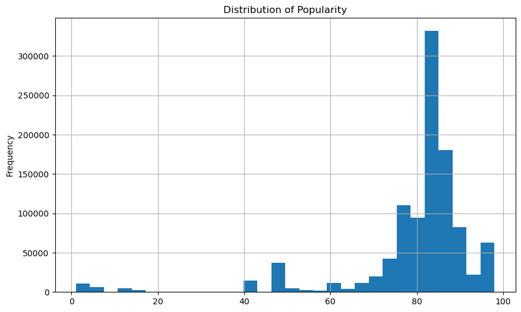

```python
# Distribution of popularity
combined_df['popularity'].plot(kind='hist', bins=30, title='Distribution of Popularity', grid=True, figsize=(10, 6))
```

Okay so most songs have a popularity between 70 and 90. We are mostly interested in the most popular songs so 80 and above

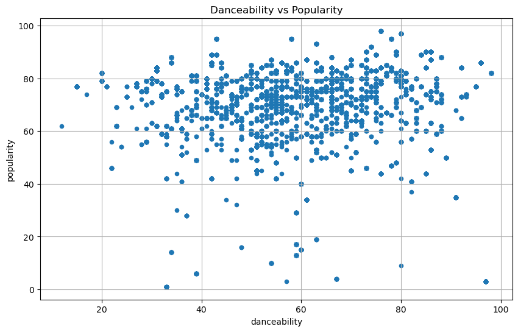

```python
# Scatter plot for danceability vs popularity
combined_df.plot(kind='scatter', x='danceability', y='popularity', title='Danceability vs Popularity', grid=True, figsize=(10, 6))
```

Okay, so most songs have a danceability between 40 and 80 and a popularity between 40 and 80. There are some outliers with very low danceability or popularity. No clear trend between danceability and popularity. Popular songs can have any danceability score. To ensure we didn't miss a relation we calculate the correlation:

```python
combined_df['danceability'].corr(combined_df['popularity'])
```

```
0.16106850889465724
```

The correlation coefficient between danceability and popularity is approximately 0.16. This indicates a very weak positive relationship, suggesting that there is no significant correlation between how danceable a song is and its popularity. Popular songs can have any danceability score.

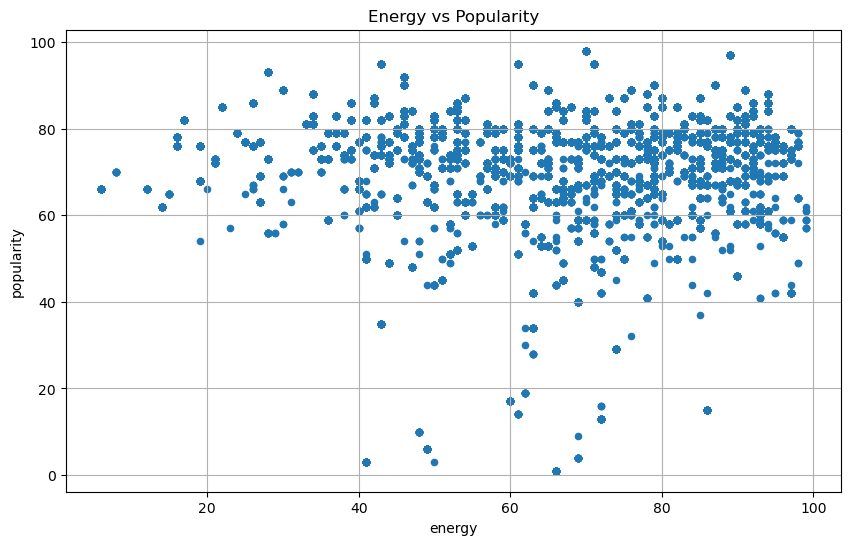

```python
# Scatter plot for energy vs popularity
combined_df.plot(kind='scatter', x='energy', y='popularity', title='Energy vs Popularity', grid=True, figsize=(10, 6))
```

Again, most songs have an energy between 40 and 80 and a popularity between 40 and 80. There are some outliers with very low energy or popularity. No clear trend between energy and popularity. Popular songs can have any energy score. To ensure there's no significant relationship between energy and popularity, we should calculate the correlation coefficient:

```python
combined_df['energy'].corr(combined_df['popularity'])
```

```
-0.10832561512468925
```

The correlation coefficient between energy and popularity is approximately -0.11. This indicates a very weak negative relationship, suggesting that there is no significant correlation between how energetic a song is and its popularity. Popular songs can have any energy score.

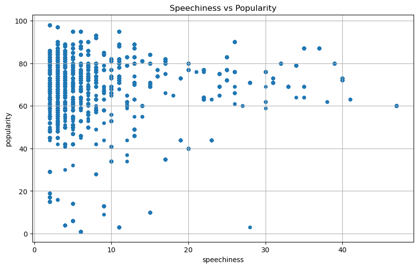

```python
# Scatter plot for speechiness vs popularity
combined_df.plot(kind='scatter', x='speechiness', y='popularity', title='Speechiness vs Popularity', grid=True, figsize=(10, 6))
```

Most songs have a speechiness between 0 and 10 and a popularity between 40 and 80. There are some outliers with higher speechiness or lower popularity. No clear trend between speechiness and popularity. Popular songs can have any speechiness score.

```python
combined_df['speechiness'].corr(combined_df['popularity'])
```

```
0.037674018991109566
```

The correlation coefficient between speechiness and popularity is approximately 0.04. This indicates a very weak positive relationship, suggesting that there is no significant correlation between how speechy a song is and its popularity. Popular songs can have any speechiness score.

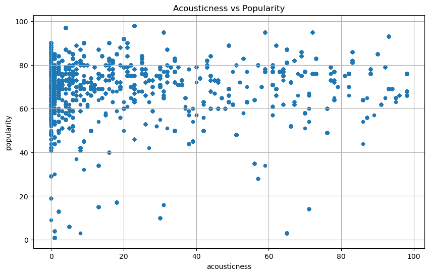

```python
# Scatter plot for acousticness vs popularity
combined_df.plot(kind='scatter', x='acousticness', y='popularity', title='Acousticness vs Popularity', grid=True, figsize=(10, 6))
```

Most songs have an acousticness between 0 and 20 and a popularity between 40 and 80. There are some outliers with higher acousticness or lower popularity. No clear trend between acousticness and popularity. Popular songs can have any acousticness score.

```python
combined_df['acousticness'].corr(combined_df['popularity'])
```

```
0.2170364723944384
```

The correlation coefficient between acousticness and popularity is approximately 0.22. This indicates a weak positive relationship, suggesting that there is a slight tendency for more acoustic songs to be more popular, but the correlation is not strong.

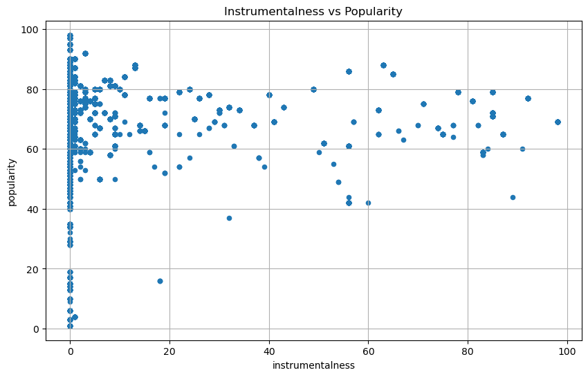

```python
# Scatter plot for instrumentalness vs popularity
combined_df.plot(kind='scatter', x='instrumentalness', y='popularity', title='Instrumentalness vs Popularity', grid=True, figsize=(10, 6))
```

Most songs have an instrumentalness between 0 and 10 and a popularity between 40 and 80. There are some outliers with higher instrumentalness or lower popularity. No clear trend between instrumentalness and popularity. Popular songs can have any instrumentalness score.

```python
combined_df['instrumentalness'].corr(combined_df['popularity'])
```

```
0.05390344543916585
```

The correlation coefficient between instrumentalness and popularity is approximately 0.05. This indicates a very weak positive relationship, suggesting that there is no significant correlation between how instrumental a song is and its popularity. Popular songs can have any instrumentalness score.

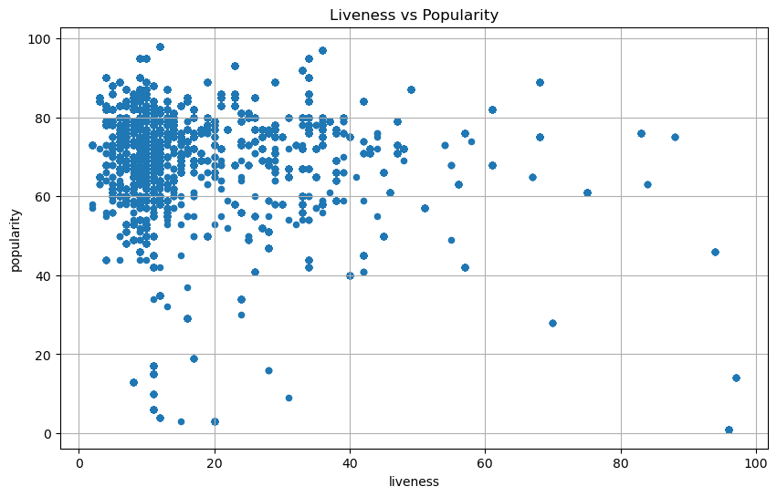

```python
# Scatter plot for liveness vs popularity
combined_df.plot(kind='scatter', x='liveness', y='popularity', title='Liveness vs Popularity', grid=True, figsize=(10, 6))
```

Most songs have a liveness between 0 and 20 and a popularity between 40 and 80. There are some outliers with higher liveness or lower popularity. No clear trend between liveness and popularity. Popular songs can have any liveness score.

```python
combined_df['liveness'].corr(combined_df['popularity'])
```

```
-0.3514771136269734
```

The correlation coefficient between liveness and popularity is approximately -0.35. This indicates a moderate negative relationship, suggesting that as liveness increases, popularity tends to decrease, but the correlation is not very strong.

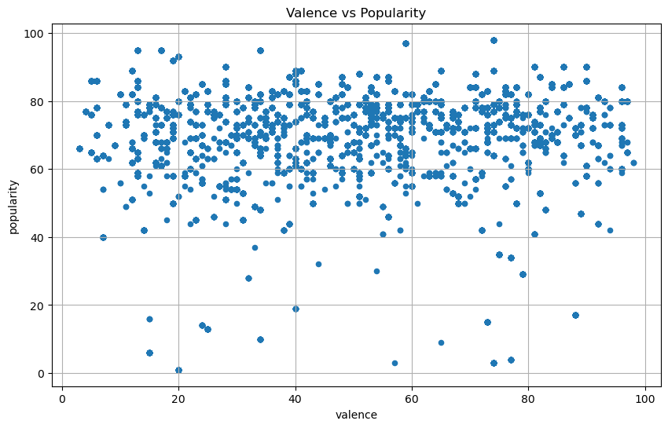

```python
# Scatter plot for valence vs popularity
combined_df.plot(kind='scatter', x='valence', y='popularity', title='Valence vs Popularity', grid=True, figsize=(10, 6))
```

Most songs have a valence between 20 and 80 and a popularity between 40 and 80. There are some outliers with lower valence or lower popularity. No clear trend between valence and popularity. Popular songs can have any valence score.

```python
combined_df['valence'].corr(combined_df['popularity'])
```

```
0.01873404521680896
```

The correlation coefficient between valence and popularity is approximately 0.02. This indicates a very weak positive relationship, suggesting that there is no significant correlation between how happy or sad a song is and its popularity. Popular songs can have any valence score.

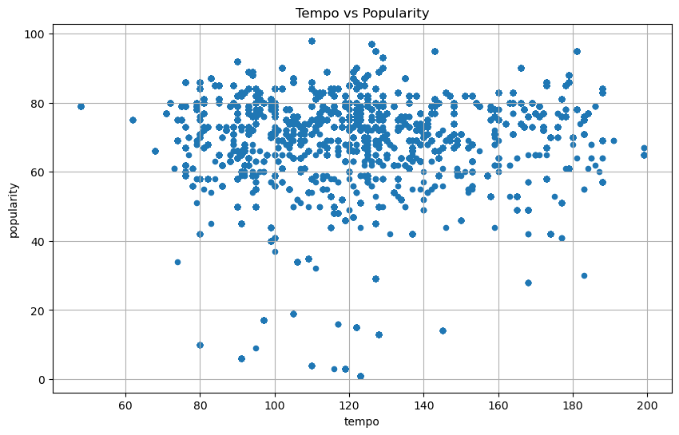

```python
# Scatter plot for tempo vs popularity
combined_df.plot(kind='scatter', x='tempo', y='popularity', title='Tempo vs Popularity', grid=True, figsize=(10, 6))
```

Most songs have a tempo between 80 and 120 and a popularity between 40 and 80. There are some outliers with higher tempo or lower popularity. No clear trend between tempo and popularity. Popular songs can have any tempo score.

```python
combined_df['tempo'].corr(combined_df['popularity'])
```

```
-0.009190458014226164
```

The correlation coefficient between tempo and popularity is approximately -0.01. This indicates a very weak negative relationship, suggesting that there is no significant correlation between the tempo of a song and its popularity. Popular songs can have any tempo score.

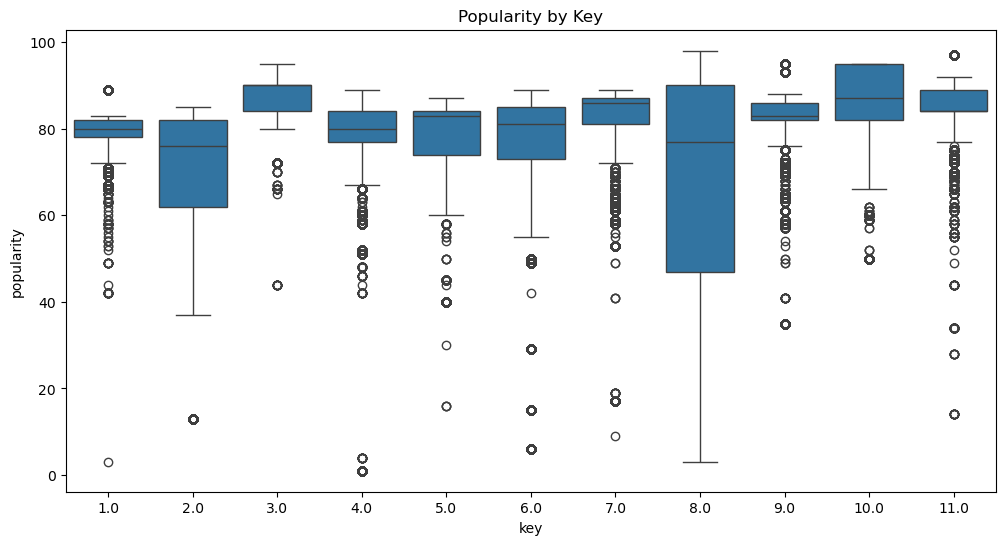

```python
# Box plot for key vs popularity
plt.figure(figsize=(12, 6))
sns.boxplot(data=combined_df, x='key', y='popularity')
plt.title('Popularity by Key')
```

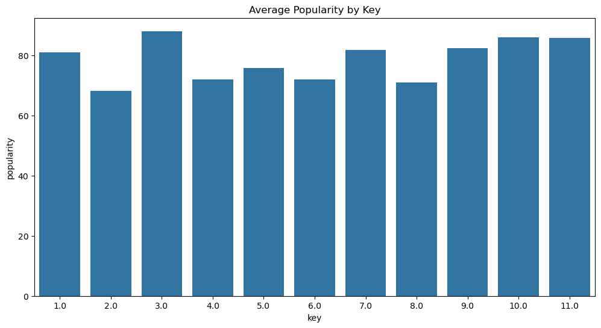

```python
# Bar plot for key vs popularity
plt.figure(figsize=(12, 6))
sns.barplot(data=combined_df, x='key', y='popularity', errorbar=None)
plt.title('Average Popularity by Key')
```

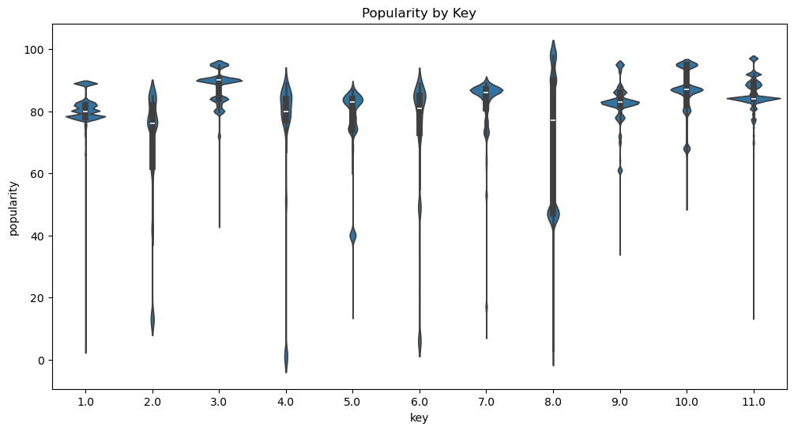

```python
# Violin plot for key vs popularity
plt.figure(figsize=(12, 6))
sns.violinplot(data=combined_df, x='key', y='popularity')
plt.title('Popularity by Key')
```

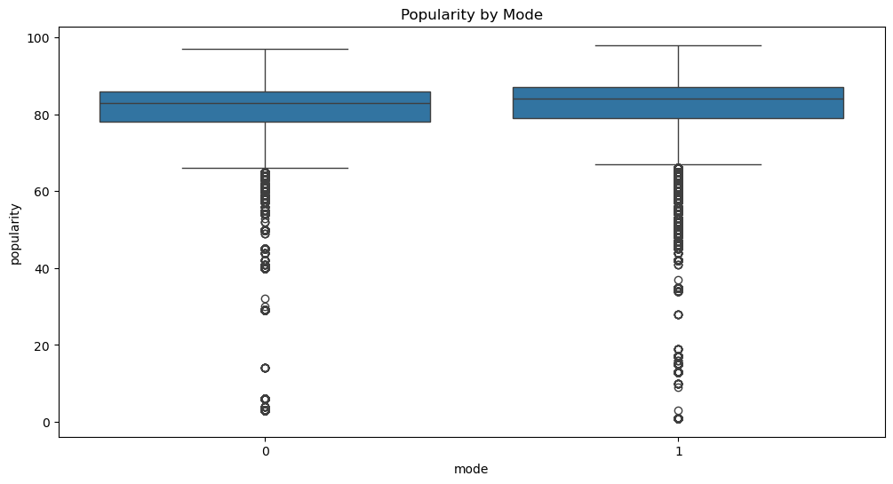

```python
# Box plot for mode vs popularity
plt.figure(figsize=(12, 6))
sns.boxplot(data=combined_df, x='mode', y='popularity')
plt.title('Popularity by Mode')
```

The box plot shows that both minor (0) and major (1) modes have similar popularity distributions. Both have a median popularity around 80, with a similar spread. There are many outliers in both modes, indicating that there are songs in both minor and major modes that are much less popular than the median.

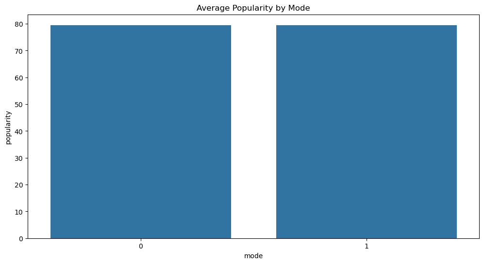

```python
# Bar plot for mode vs popularity
plt.figure(figsize=(12, 6))
sns.barplot(data=combined_df, x='mode', y='popularity', errorbar=None)
plt.title('Average Popularity by Mode')
```

The bar plot shows that the average popularity for songs in minor (0) and major (1) modes is almost identical, both around 80. This suggests that there is no significant difference in average popularity between songs in minor and major modes.

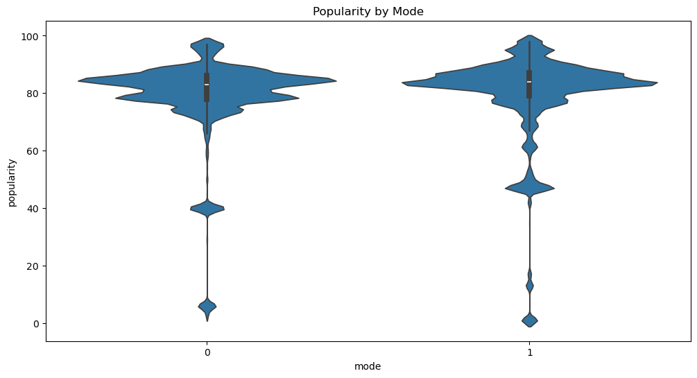

```python
# Violin plot for mode vs popularity
plt.figure(figsize=(12, 6))
sns.violinplot(data=combined_df, x='mode', y='popularity')
plt.title('Popularity by Mode')
```

Same as before, the violin plot shows that both minor (0) and major (1) modes have a high concentration of popularity around 80. The distribution is similar for both modes, with some variability and outliers. Most songs in both modes tend to have similar popularity scores.

```
([0, 1, 2, 3, 4, 5, 6, 7, 8, 9, 10],
 [Text(0, 0, '0'),
```

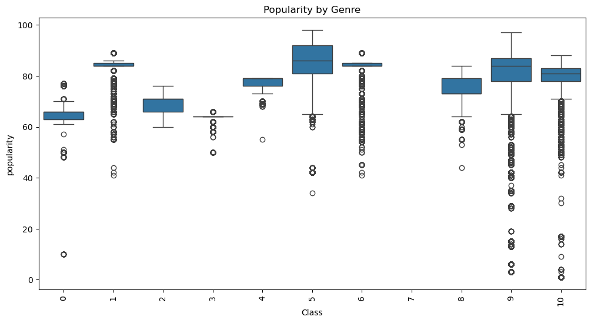

```python
# Box plot for genre vs popularity
plt.figure(figsize=(12, 6))
sns.boxplot(data=combined_df, x='Class', y='popularity')
plt.title('Popularity by Genre')
plt.xticks(rotation=90)
```

```
([0, 1, 2, 3, 4, 5, 6, 7, 8, 9, 10],
 [Text(0, 0, '0'),
```

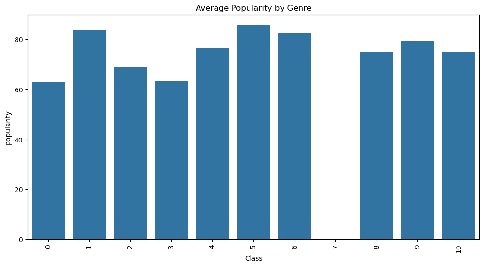

```python
# Bar plot for genre vs popularity
plt.figure(figsize=(12, 6))
sns.barplot(data=combined_df, x='Class', y='popularity', errorbar=None)
plt.title('Average Popularity by Genre')
plt.xticks(rotation=90)
```

The bar plot shows the average popularity for each genre. Genre 5 has the highest average popularity, followed by genres 1 and 6. Genres 2, 3, and 0 have lower average popularity. Most genres have an average popularity between 60 and 80, indicating some variability in how popular songs are within each genre.

```
([0, 1, 2, 3, 4, 5, 6, 7, 8, 9, 10],
 [Text(0, 0, '0'),
```

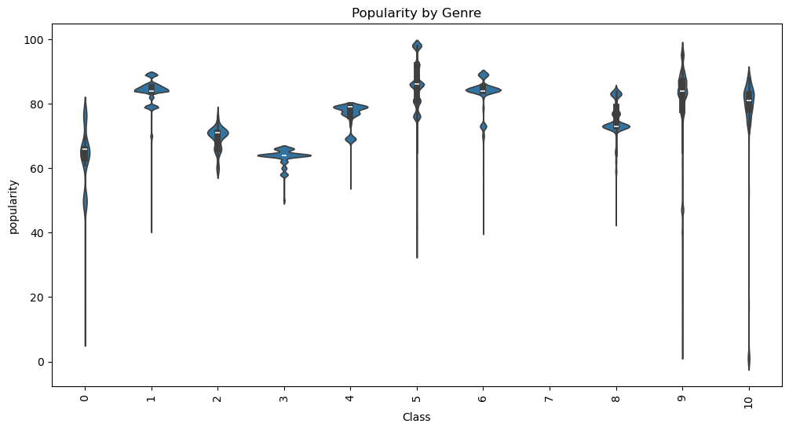

```python
# Violin plot for genre vs popularity
plt.figure(figsize=(12, 6))
sns.violinplot(data=combined_df, x='Class', y='popularity')
plt.title('Popularity by Genre')
plt.xticks(rotation=90)
```

## Conclusion

In exploring the dataset to answer the research question, "What factors contribute to a song's popularity?" the following key observations and conclusions were drawn:

#### Distribution of Popularity

- Most songs have a popularity score between 70 and 90, with the most popular songs having scores of 80 and above.

#### Danceability vs Popularity

- No significant correlation between danceability and popularity (correlation coefficient: 0.16). Popular songs can have any danceability score.

#### Energy vs Popularity

- No significant correlation between energy and popularity (correlation coefficient: -0.11). Popular songs can have any energy score.

#### Speechiness vs Popularity

- No significant correlation between speechiness and popularity (correlation coefficient: 0.04). Popular songs can have any speechiness score.

#### Acousticness vs Popularity

- Weak positive correlation between acousticness and popularity (correlation coefficient: 0.22). Slight tendency for more acoustic songs to be more popular, but not strong.

#### Instrumentalness vs Popularity

- No significant correlation between instrumentalness and popularity (correlation coefficient: 0.05). Popular songs can have any instrumentalness score.

#### Liveness vs Popularity

- Moderate negative correlation between liveness and popularity (correlation coefficient: -0.35). As liveness increases, popularity tends to decrease, but the correlation is not very strong.

#### Valence vs Popularity

- No significant correlation between valence and popularity (correlation coefficient: 0.02). Popular songs can have any valence score.

#### Tempo vs Popularity

- No significant correlation between tempo and popularity (correlation coefficient: -0.01). Popular songs can have any tempo score.

#### Mode vs Popularity

- Both minor (0) and major (1) modes have similar popularity distributions, with a median popularity around 80.
- No significant difference in average popularity between songs in minor and major modes.

### What would I do if I had additional time

1. **Expand Dataset**: It seems that we didn't reach a clear conclusion because we used Spotify charts dataset. Next time I should also add another dataset that includes non-popular songs on spotify so that we can get a less biased result.
2. **Include More Features**: Explore additional features such as lyrical content, release year, and artist popularity to gain deeper insights into what drives a song's popularity.
3. **Work on Popular_Spotify_Songs.csv**: If I had more time, I would further clean the third dataset and merge it with the other datasets and see the result. I only added this third dataset because I couldn't find tidiness issues in the first two.

### Final Thoughts

Based on the analysis, it appears that factors such as danceability, energy, speechiness, acousticness, instrumentalness, liveness, valence, and tempo have very weak or no significant correlation with a song's popularity. However, key and genre show some variability in popularity distribution, with certain keys and genres showing a tendency to be more popular. Overall, popularity seems to be influenced by a complex interplay of various factors, and no single attribute strongly determines a song's popularity.